# Proyecto entrega 5

- Antonio Lomelí Ureña - Carolina Martínez - Enrique Tonatiuh Pérez Cortés - Eddie Aguilar

2024-05-06

## Introducción

El Value at Risk representa la pérdida máxima esperada en un periodo de tiempo. Para calcularlo, exiten distintos métodos que serñan expuestos y explicados en este entregable. A lo largo del proyecto, se trabajará con el activo de refrencia de este proyecto (FEMSA) y se agregará un segundo activo perteniciente a la Bolsa Mexicana de Valores con la finalidad de armar un portafolio y trabajar sobre él. Se calculará el VaR con la metodología paramétrica y no paramétrica para 4 distintos periodos de tiempo y con distintos niveles de confianza y se aplicará una prueba para determinar si el valor obtenido se encuentra subestiamdo, sobreestimado o correcto. También se presentará una gráfica para visualizar los rendimientos obtenidos y se propondrá un portafolio óptimo, explicando su composición.

## Construcción del portafolio

Para fines de esta entrega, se trabajará con un portafolio conformado únicamente de 2 acciones: FEMSA, al ser el activo principal del proyecto, y CEMEX, al ser una acción que también cotiza en la BMV. En este caso, el portafolio estará conformado por 200 acciones, divididas en partes iguales entre ambos activos.

Sabemos que el VaR se calcula utilizando el precio inicial del portafolio, la volatilidad de este y un valor de z que dependerá del nivel de confianza deseado.

$$VaR = V_o \sigma Z_\alpha$$

**Valor inicial**

Para poder realizar los cálculos necesarios posteriores, se calcula el valor inicial del portafolio multiplicando el precio de cada activo por la cantidad de activos correspondiente.

```
## [1] 21272
```

El valor inicial del portafolio es $21,272.00

Posteriormente, se calculará la volatilidad del portafolio. Para ello se calcula el vector de pesos y la matriz de varianza - corvarianza.

**Vector de pesos**

```
## [1] 0.93489093 0.06510907
```

Por lo tanto, 93.48% para FEMSA y 6.51% para CEMEX

**Matriz de varianzas y covarianzas**

Viendo ahora la matriz de varianzas y covarianzas:

```
##                      FEMSAUBD.MX.Adjusted CEMEXCPO.MX.Adjusted
## FEMSAUBD.MX.Adjusted         3.396656e-04        -5.963418e-06
## CEMEXCPO.MX.Adjusted        -5.963418e-06         3.805350e-04
```

**Volatilidad de portafolio**

Se calcula la volatilidad del portafolio utilizando la siguiente fórmula:
$$\sigma=\sqrt{wCw^T}$$

```
##            [,1]
## [1,] 0.01725578
```

Tenemos que la volatilidad del portafolio es de 0.0172

## VaR paramétrico

Para 1, 5, 10 y 20 días.

Apoyados de los valores de z correspondientes, se calcula el VaR en las distintas temporalidades que se solicitan y con 3 niveles de confianza: 90% ,95% y 99%.

```
##         1 día    5 días   10 días   20 días
## 90% -470.4128 -1051.875 -1487.576 -2103.750
## 95% -603.7683 -1350.067 -1909.283 -2700.134
## 99% -853.9210 -1909.425 -2700.335 -3818.851
```

## Back testing

A continuación, se aplicará la prueba “Back Testing” con la finalidad de evaluar los resultados obtenidos. Para este caso, solo se utilizará el VaR a un día en los tres niveles de confianza propuestos.

- Primero, se realiza la función de pérdidas y ganacias.
- Después, se realiza la prueba con los valores obtenidos para el VaR a un día con los distintos niveles de confianza.
- Finalmente tenemos los valores de nuestro back test:

```
##         90%        95%        99%
##  0.05932203 0.02542373 0.01694915
```

Se observa que en el caso del 90% y 95% el cálculo del VaR resulta exitoso al no salirse del nivel de confianza establecido. Sin embargo, en el caso del 99% de confianza se puede decir que está ligeramente subestimado, ya que excede 0.7 el nivel de confianza. Para ello, se utilizará el percentil correspondiente en la función de pérdidas y ganancias para poder establecer un valor que se ajuste de mejor manera.

```
##       1%
## -1216.59
```

Se obtiene un VaR al 99% de confianza a un día de -$1216.59, una cantidad mayor a la previamente calculada, ya que como se mencionó anteriormente, esta se encontraba subestimada.

## VaR no paramétrico

Calculamos:

- Vf para 1 día.
- Vf para 5 días.
- Vf para 10 días.
- Vf para 20 días.

### Funciones de pérdidas y ganancias

Posteriormente, vemos las funciones de pérdidas y ganancias para cada temporalidad:

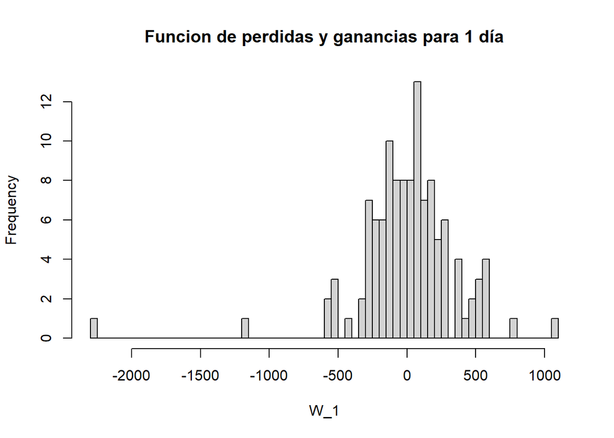

```r
W_1 <- VF_1-v0
W_5 <- VF_5-v0
W_10 <- VF_10-v0
W_20 <- VF_20-v0

hist(W_1, n=100, main="Funcion de perdidas y ganancias para 1 día")
```

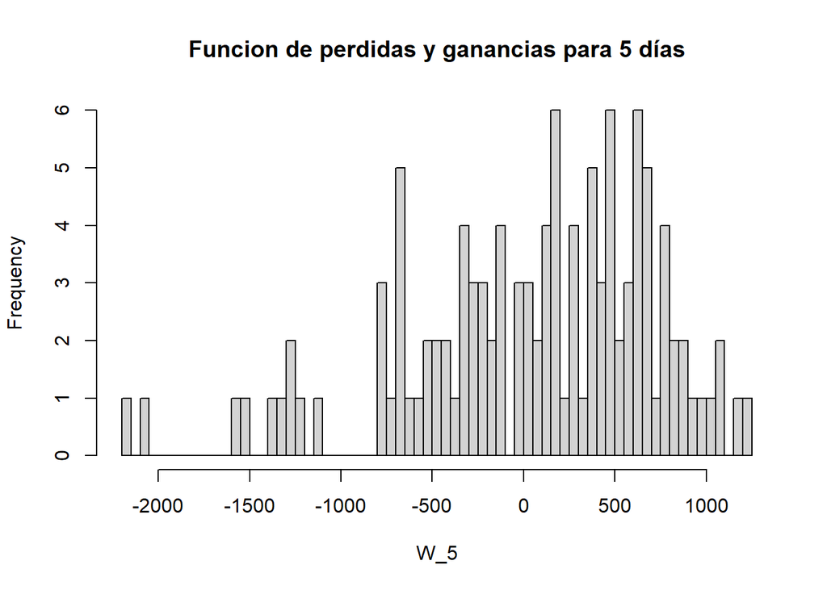

```r
hist(W_5, n=100, main="Funcion de perdidas y ganancias para 5 días")
```

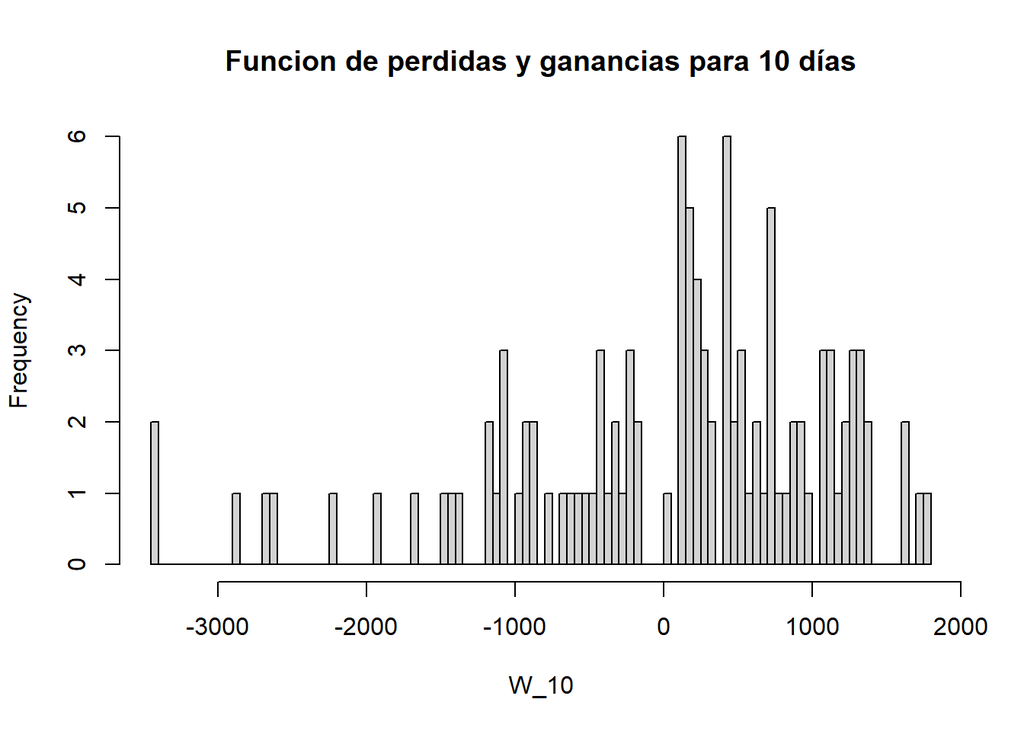

```r
hist(W_10, n=100, main="Funcion de perdidas y ganancias para 10 días")
```

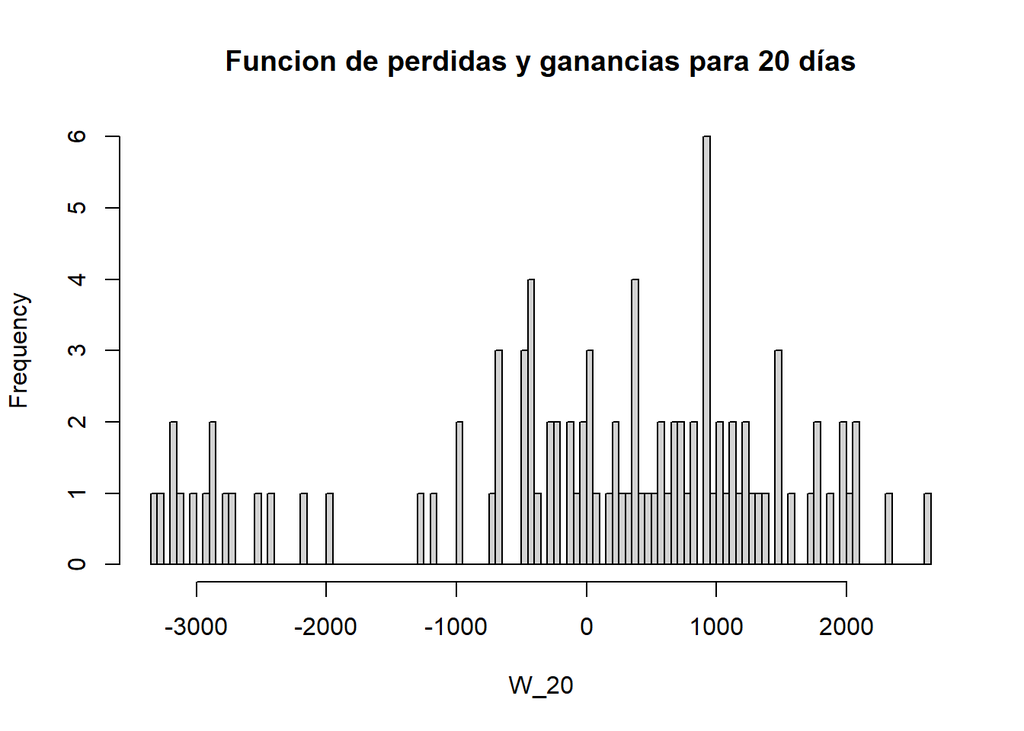

```r
hist(W_20, n=100, main="Funcion de perdidas y ganancias para 20 días")
```

Y por último, tenemos nuestros VaRs mediante los percentiles adecuados:

```
##          1 día     5 días   10 días   20 días
## 90%  -285.9070  -769.9104 -1206.969 -2725.644
## 95%  -508.3115 -1311.0712 -2113.069 -3037.506
## 99% -1091.8044 -2029.4829 -3368.482 -3251.598
```

### Gráfica de VaRs

Gráfica de funciones de pérdidas y ganancias, y sus VaRs adecuados para 1 día:

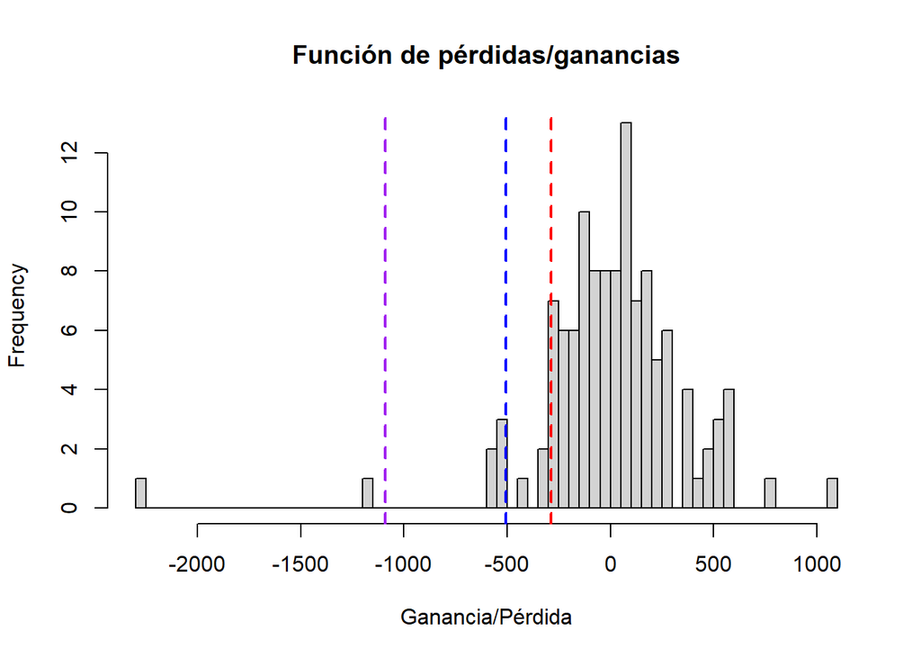

```r
hist(W_1, 100, main="Función de pérdidas/ganancias", xlab="Ganancia/Pérdida")
abline(v = VaR_NP_90_1, lwd=2, col="red", lty=2)
abline(v = VaR_NP_95_1, lwd=2, col="blue", lty=2)
abline(v = VaR_NP_99_1, lwd=2, col="purple", lty=2)
```

### Back testing

Ahora aplicará la prueba “Back Testing” para la metodología no paramétrica. Al igual que en el caso anterior, solo se utilizará el VaR a un día en los tres niveles de confianza propuestos.

La funcion de perdidas y ganancias es la misma asi que se utilizara la que ya se habia realizado, lo que sigue es hacer la prueba con los valores obtenidos para el VaR a un día con los distintos niveles de confianza.

```
##        90%        95%        99%
##  0.1016949 0.05084746 0.01694915
```

La prueba de backtesting indica que el VaR al 90% y al 95% está siendo levemente subestimada, la diferencia en el VaR al 99% es más significativa. Revisamos los valores del VaR con los datos reales para proponer nuevos valores del value at risk y entender de dónde viene esta diferencia.

```r
quantile(p_g_real,0.1)
```

```
##       10%
## -285.2362
```

```r
quantile(p_g_real,0.05)
```

```
##        5%
## -505.9157
```

```r
quantile(p_g_real,0.01)
```

```
##       1%
## -1216.59
```

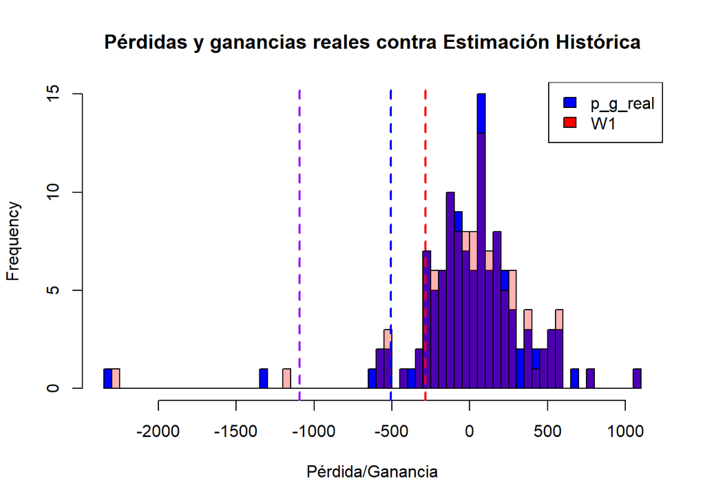

```r
hist(p_g_real, main="Pérdidas y ganancias reales contra Estimación Histórica", xlab = "Pérdida/Ganancia", n=100, col="blue")

hist(W_1, add=TRUE, col=rgb(1, 0, 0, alpha=0.3), n=100)

legend("topright", legend=c("p_g_real", "W1"), fill=c("blue", "red"))
abline(v = VaR_NP_90_1, lwd=2, col="red", lty=2)
abline(v = VaR_NP_95_1, lwd=2, col="blue", lty=2)
abline(v = VaR_NP_99_1, lwd=2, col="purple", lty=2)
```

Observando los valores del VaR como percentiles de la pérdida y ganancia real, y contrastando en el histograma los valores reales con la estimación, podemos concluir que las estimaciones del VaR no paramétrico son buenas.

Esto también demuestra la utilidad del backtesting, del VaR y de las visualizaciones, combinando todo esto podemos darnos cuenta de más cosas y obtener mejores insights de lo que puede pasar con nuestro portafolio y modelos.

## Composición óptima del portafolio

La composición óptima del portafolio es aquella que minimiza el valor del VaR para el portafolio en cuestión. Por lo tanto, buscamos los pesos de ambos activos que hacen esta composición. El peso del primer activo está dada por:

$$w_1 =
\frac{2\sigma_2^2-2\sigma_{12}}{2\sigma_1^2+2\sigma_2^2-4\sigma_{12}}$$
Y por consiguiente el segundo peso será:

$$w_2 = 1 - w_1$$

Peso 1:

```
## [1] 0.5279114
```

Peso 2:

```
## [1] 0.4720886
```

Por lo tanto, tenemos que nuestro portafolio óptimo que minimiza el VaR es aquel de 52.79% de FEMSA y 47.2% de CEMEX.